# Ejemplo aplicando diferentes modelos

Mayo 2024

Tareas Teoría de Decisiones:

1. Ejercicios 3, 4 y 5 del Capítulo 2.
2. Ejercicios Capítulo 5.
3. Ejemplos realizados el 23 de mayo.

Subir los archivos a su cuenta de GitHub a más tardar el sábado 25 de mayo.

# Conjunto de datos ModeCanada

Trabajaremos con los datos *ModeCanada* del package *mlogit* el cual consiste de las opciones de transporte entre Montreal y Toronto. Está en formato por longitud con las siguientes variables:

- case: the individual index,
- alt: the alternative, one of train, car, bus and air,
- choice: one if the mode is chosen, zero otherwise,
- cost: monetary cost,
- ivt: in vehicule time,
- ovt: out vehicule time,
- frequency: frequency,
- income: income,
- urban: urban,
- noalt: the number of alternatives available.

```r
data("ModeCanada", package = "mlogit")
glimpse(ModeCanada)
```

```
## Rows: 15,520
## Columns: 11
## $ case   <int> 1, 1, 2, 2, 3, 3, 4, 4, 5, 5, 6, 6, 7, 7, 8, 8, 9, 9, 10, 10, 1…
## $ alt    <fct> train, car, train, car, train, car, train, car, train, car, tra…
## $ choice <int> 0, 1, 0, 1, 0, 1, 0, 1, 0, 1, 0, 1, 0, 1, 0, 1, 0, 1, 0, 1, 0, …
## $ dist   <int> 83, 83, 83, 83, 83, 83, 83, 83, 83, 83, 83, 83, 83, 83, 83, 83,…
## $ cost   <dbl> 28.25, 15.77, 28.25, 15.77, 28.25, 15.77, 28.25, 15.77, 28.25, …
## $ ivt    <int> 50, 61, 50, 61, 50, 61, 50, 61, 50, 61, 50, 61, 50, 61, 50, 61,…
## $ ovt    <int> 66, 0, 66, 0, 66, 0, 66, 0, 66, 0, 66, 0, 66, 0, 66, 0, 66, 0, …
## $ freq   <int> 4, 0, 4, 0, 4, 0, 4, 0, 4, 0, 4, 0, 4, 0, 4, 0, 4, 0, 4, 0, 4, …
## $ income <int> 45, 45, 25, 25, 70, 70, 70, 70, 55, 55, 70, 70, 15, 15, 15, 15,…
## $ urban  <int> 0, 0, 0, 0, 0, 0, 0, 0, 0, 0, 0, 0, 0, 0, 0, 0, 0, 0, 0, 0, 0, …
## $ noalt  <int> 2, 2, 2, 2, 2, 2, 2, 2, 2, 2, 2, 2, 2, 2, 2, 2, 2, 2, 2, 2, 2, …
```

Cambiamos el tipo de algunas variables:

```r
ModeCanada$dist <- as.numeric(ModeCanada$dist)
ModeCanada$income <- as.numeric(ModeCanada$income)
```

Observamos que no todas las personas tienen todas las alternativas disponibles, se filtra un subconjunto con disponibilidad completa:

```r
ModeCanadafilter <- ModeCanada |> filter(noalt == 4)

MC <- mlogit.data(ModeCanada |>
filter(noalt == 4),
choice = "choice",
shape = "long",
alt.levels = c("air",
"train",
"bus",
"car"))
```

## Gráficas

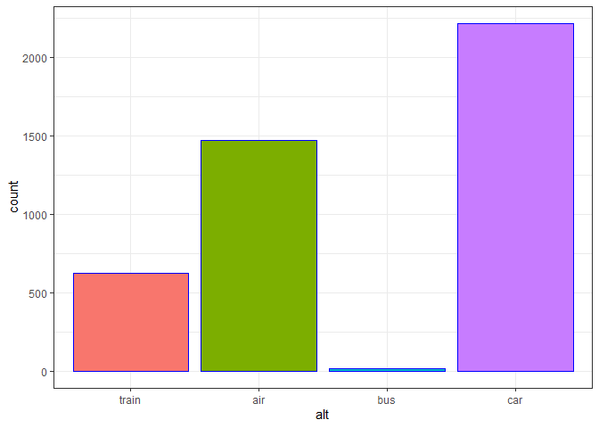

```r
ggplot(ModeCanada |> filter(choice==1))+
  geom_bar(aes(alt, fill=alt), color= "blue", show.legend= FALSE)+
  theme_bw()
```

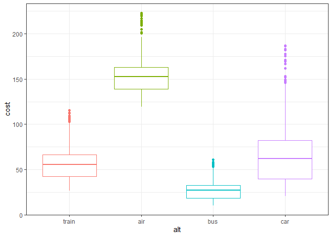

```r
ggplot(ModeCanadafilter)+
  geom_boxplot(aes(alt, cost, color= alt), show.legend = FALSE)+
  theme_bw()
```

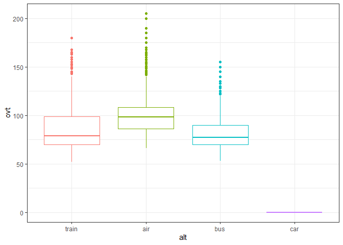

```r
ggplot(ModeCanadafilter)+

  geom_boxplot(aes(alt, ovt, color=alt), show.legend = FALSE)+

  theme_bw()
```

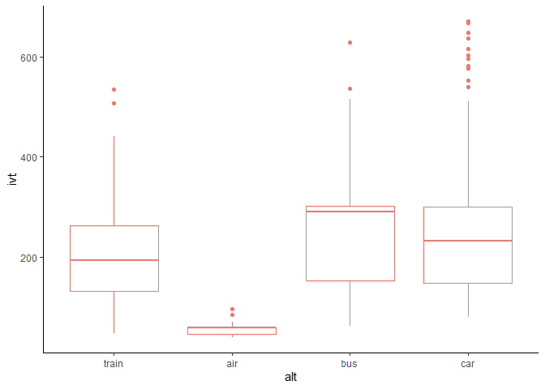

```r
ggplot(ModeCanadafilter)+
  geom_boxplot(aes(alt, ivt, color="alt"
                   ), show.legend = FALSE )+
  theme_classic()
```

## Módelo Logit simple considerando el costo

```r
ml1 <- mlogit(choice ~ cost, MC)
summary(ml1)
```

```
##
## Call:
## mlogit(formula = choice ~ cost, data = MC, method = "nr")
##
## Frequencies of alternatives:choice
##     train       air       bus       car
## 0.1666067 0.3738755 0.0035984 0.4559194
##
## nr method
## 8 iterations, 0h:0m:0s
## g'(-H)^-1g = 0.000489
## successive function values within tolerance limits
##
## Coefficients :
##                   Estimate Std. Error z-value  Pr(>|z|)
## (Intercept):air  6.3757428  0.2668267  23.895 < 2.2e-16 ***
## (Intercept):bus -5.7450972  0.3357461 -17.111 < 2.2e-16 ***
## (Intercept):car  1.5638334  0.0633645  24.680 < 2.2e-16 ***
## cost            -0.0567919  0.0026439 -21.481 < 2.2e-16 ***
## ---
## Signif. codes:  0 '***' 0.001 '**' 0.01 '*' 0.05 '.' 0.1 ' ' 1
##
## Log-Likelihood: -2633.8
## McFadden R^2:  0.092839
## Likelihood ratio test : chisq = 539.09 (p.value = < 2.22e-16)
```

## Módelo Logit simple considerando el costo, ivt y ovt

```r
ml1 <- mlogit(choice ~ cost + ivt + ovt, MC)
summary(ml1)
```

```
##
## Call:
## mlogit(formula = choice ~ cost + ivt + ovt, data = MC, method = "nr")
##
## Frequencies of alternatives:choice
##     train       air       bus       car
## 0.1666067 0.3738755 0.0035984 0.4559194
##
## nr method
## 8 iterations, 0h:0m:0s
## g'(-H)^-1g = 0.000112
## successive function values within tolerance limits
##
## Coefficients :
##                    Estimate  Std. Error  z-value  Pr(>|z|)
## (Intercept):air -0.53728903  0.40904587  -1.3135     0.189
## (Intercept):bus -3.98003728  0.33187647 -11.9925 < 2.2e-16 ***
## (Intercept):car -1.75907547  0.21742130  -8.0906 6.661e-16 ***
## cost            -0.01503560  0.00364080  -4.1297 3.632e-05 ***
## ivt             -0.01907942  0.00079325 -24.0521 < 2.2e-16 ***
## ovt             -0.03768373  0.00263374 -14.3081 < 2.2e-16 ***
## ---
## Signif. codes:  0 '***' 0.001 '**' 0.01 '*' 0.05 '.' 0.1 ' ' 1
##
## Log-Likelihood: -2190.5
## McFadden R^2:  0.24554
## Likelihood ratio test : chisq = 1425.8 (p.value = < 2.22e-16)
```

## Modelo logit multinomial, considerando dist como atributo del decisor

```r
ml3 <- mlogit(choice ~ cost+ivt+ovt | dist,MC)
 summary(ml3)
```

```
##
## Call:
## mlogit(formula = choice ~ cost + ivt + ovt | dist, data = MC,
##     method = "nr")
##
## Frequencies of alternatives:choice
##     train       air       bus       car
## 0.1666067 0.3738755 0.0035984 0.4559194
##
## nr method
## 8 iterations, 0h:0m:0s
## g'(-H)^-1g = 3.41E-07
## gradient close to zero
##
## Coefficients :
##                    Estimate  Std. Error  z-value  Pr(>|z|)
## (Intercept):air -3.86564744  0.59371944  -6.5109  7.47e-11 ***
## (Intercept):bus -2.58297555  0.85543609  -3.0195 0.0025321 **
## (Intercept):car -0.42881687  0.24820146  -1.7277 0.0840426 .
## cost             0.02301445  0.00671444   3.4276 0.0006089 ***
## ivt             -0.01036296  0.00174130  -5.9513  2.66e-09 ***
## ovt             -0.04607599  0.00324081 -14.2175 < 2.2e-16 ***
## dist:air         0.00286941  0.00113925   2.5187 0.0117797 *
## dist:bus        -0.00211674  0.00298569  -0.7090 0.4783469
## dist:car        -0.00821252  0.00081702 -10.0517 < 2.2e-16 ***
## ---
## Signif. codes:  0 '***' 0.001 '**' 0.01 '*' 0.05 '.' 0.1 ' ' 1
##
## Log-Likelihood: -2080.1
## McFadden R^2:  0.28355
## Likelihood ratio test : chisq = 1646.5 (p.value = < 2.22e-16)
```

```r
ml4 <- mlogit(choice ~ ivt+ovt|0|cost,MC)
 summary(ml4)
```

```
##
## Call:
## mlogit(formula = choice ~ ivt + ovt | 0 | cost, data = MC, method = "nr")
##
## Frequencies of alternatives:choice
##     train       air       bus       car
## 0.1666067 0.3738755 0.0035984 0.4559194
##
## nr method
## 8 iterations, 0h:0m:0s
## g'(-H)^-1g = 2.36E-08
## gradient close to zero
##
## Coefficients :
##              Estimate Std. Error  z-value  Pr(>|z|)
## ivt        -0.0153086  0.0018413  -8.3140 < 2.2e-16 ***
## ovt        -0.0455489  0.0030556 -14.9068 < 2.2e-16 ***
## cost:train  0.0196465  0.0111506   1.7619   0.07808 .
## cost:air   -0.0014815  0.0028152  -0.5263   0.59870
## cost:bus   -0.1126096  0.0279219  -4.0330 5.506e-05 ***
## cost:car   -0.0270065  0.0069274  -3.8985 9.679e-05 ***
## ---
## Signif. codes:  0 '***' 0.001 '**' 0.01 '*' 0.05 '.' 0.1 ' ' 1
##
## Log-Likelihood: -2123.2
```

## Modelo anidado: Set1 (rapido) y Set2(lento)

```r
nl1 <- mlogit(choice ~ cost+ivt+ovt, MC, nests = list(set1=c('air', 'car'), set2=c('train', 'bus')), stepol=1e-12)

summary(nl1)
```

```
##
## Call:
## mlogit(formula = choice ~ cost + ivt + ovt, data = MC, nests = list(set1 = c("air",
##     "car"), set2 = c("train", "bus")), stepol = 1e-12)
##
## Frequencies of alternatives:choice
##     train       air       bus       car
## 0.1666067 0.3738755 0.0035984 0.4559194
##
## bfgs method
## 18 iterations, 0h:0m:0s
## g'(-H)^-1g = 4.65E-07
## gradient close to zero
##
## Coefficients :
##                    Estimate  Std. Error  z-value  Pr(>|z|)
## (Intercept):air -0.83281020  0.25413079  -3.2771  0.001049 **
## (Intercept):bus -1.55485882  1.35191684  -1.1501  0.250097
## (Intercept):car  0.12105562  0.15263215   0.7931  0.427708
## cost             0.00838598  0.00178391   4.7009  2.59e-06 ***
## ivt             -0.00893299  0.00084376 -10.5871 < 2.2e-16 ***
## ovt             -0.01511148  0.00165957  -9.1056 < 2.2e-16 ***
## iv:set1          0.28487401  0.03134564   9.0882 < 2.2e-16 ***
## iv:set2          0.49141006  0.36694371   1.3392  0.180506
## ---
## Signif. codes:  0 '***' 0.001 '**' 0.01 '*' 0.05 '.' 0.1 ' ' 1
##
## Log-Likelihood: -2131.7
## McFadden R^2:  0.26577
## Likelihood ratio test : chisq = 1543.3 (p.value = < 2.22e-16)
```

Las personas tienden a elegir la opción con el menor tiempo de espera, incluso si eso significa pagar un poco más. Por lo tanto, la opción de avión, aunque más costosa, sería la mejor. Sin embargo, en la práctica, la opción de automóvil sigue siendo la más popular.

LLEVAR A CABO LOS MODELOS LOGIT CONSIDERANDO ATRIBUTOS DE LAS ALTERNATIVAS, DECISORES

# Conjunto de datos TravelMode

Consideremos los datos *TravelMode* del package *AER* el cual consiste de las opciones de transporte entre Sidney y Melbourne. Está en formato por longitud con las siguientes variables:

- individual: Factor indicating individual with levels 1 to 210.
- mode: Factor indicating travel mode with levels “car”, “air”, “train”, or “bus”.
- choice: Factor indicating choice with levels “no” and “yes”.
- wait: Terminal waiting time, 0 for car.
- vcost: Vehicle cost component.
- travel: Travel time in the vehicle.
- gcost: Generalized cost measure.
- income: Household income.
- size: Party size.

```r
data("TravelMode", package = "AER")
glimpse(TravelMode)
```

```
## Rows: 840
## Columns: 9
## $ individual <fct> 1, 1, 1, 1, 2, 2, 2, 2, 3, 3, 3, 3, 4, 4, 4, 4, 5, 5, 5, 5,…
## $ mode       <fct> air, train, bus, car, air, train, bus, car, air, train, bus…
## $ choice     <fct> no, no, no, yes, no, no, no, yes, no, no, no, yes, no, no, …
## $ wait       <int> 69, 34, 35, 0, 64, 44, 53, 0, 69, 34, 35, 0, 64, 44, 53, 0,…
## $ vcost      <int> 59, 31, 25, 10, 58, 31, 25, 11, 115, 98, 53, 23, 49, 26, 21…
## $ travel     <int> 100, 372, 417, 180, 68, 354, 399, 255, 125, 892, 882, 720, …
## $ gcost      <int> 70, 71, 70, 30, 68, 84, 85, 50, 129, 195, 149, 101, 59, 79,…
## $ income     <int> 35, 35, 35, 35, 30, 30, 30, 30, 40, 40, 40, 40, 70, 70, 70,…
## $ size       <int> 1, 1, 1, 1, 2, 2, 2, 2, 1, 1, 1, 1, 3, 3, 3, 3, 2, 2, 2, 2,…
```

Cambiamos la clase del conjunto de datos:

```r
TM <- mlogit.data(TravelMode,
choice = "choice",
shape = "long",
alt.levels = c("air",
"train",
"bus",
"car"))
```

## Modelo de clase latentes (Q=2), considerando costo

```r
lc1 <- gmnl(choice ~ vcost | 0 | 0 | 0 | 1, data = TM, model = 'lc', Q = 2, panel = FALSE, method = "bhhh")
```

```
## Estimating LC model
```

```r
summary(lc1)
```

```
##
## Model estimated on: sáb. may. 25 03:41:15 p. m. 2024
##
## Call:
## gmnl(formula = choice ~ vcost | 0 | 0 | 0 | 1, data = TM, model = "lc",
##     Q = 2, panel = FALSE, method = "bhhh")
##
## Frequencies of categories:
##
##     air   train     bus     car
## 0.27619 0.30000 0.14286 0.28095
##
## The estimation took: 0h:0m:0s
##
## Coefficients:
##                Estimate Std. Error z-value Pr(>|z|)
## class.1.vcost -0.088322   0.043025 -2.0528  0.04009 *
## class.2.vcost  0.022222   0.010297  2.1580  0.03093 *
## (class)2       0.261221   0.493088  0.5298  0.59627
## ---
## Signif. codes:  0 '***' 0.001 '**' 0.01 '*' 0.05 '.' 0.1 ' ' 1
##
## Optimization of log-likelihood by BHHH maximisation
## Log Likelihood: -273
## Number of observations: 210
## Number of iterations: 15
## Exit of MLE: successive function values within relative tolerance limit (reltol)
```

AÑADIR MODELOS LOGIT CONSIDERANDO ATRIBUTOS DE LAS ALTERNATIVAS Y DECISORES…

```r
data("TravelMode", package = "mlogit")
glimpse(TravelMode)
```

```
## Rows: 840
## Columns: 9
## $ individual <fct> 1, 1, 1, 1, 2, 2, 2, 2, 3, 3, 3, 3, 4, 4, 4, 4, 5, 5, 5, 5,…
## $ mode       <fct> air, train, bus, car, air, train, bus, car, air, train, bus…
## $ choice     <fct> no, no, no, yes, no, no, no, yes, no, no, no, yes, no, no, …
## $ wait       <int> 69, 34, 35, 0, 64, 44, 53, 0, 69, 34, 35, 0, 64, 44, 53, 0,…
## $ vcost      <int> 59, 31, 25, 10, 58, 31, 25, 11, 115, 98, 53, 23, 49, 26, 21…
## $ travel     <int> 100, 372, 417, 180, 68, 354, 399, 255, 125, 892, 882, 720, …
## $ gcost      <int> 70, 71, 70, 30, 68, 84, 85, 50, 129, 195, 149, 101, 59, 79,…
## $ income     <int> 35, 35, 35, 35, 30, 30, 30, 30, 40, 40, 40, 40, 70, 70, 70,…
## $ size       <int> 1, 1, 1, 1, 2, 2, 2, 2, 1, 1, 1, 1, 3, 3, 3, 3, 2, 2, 2, 2,…
```

# Graficas

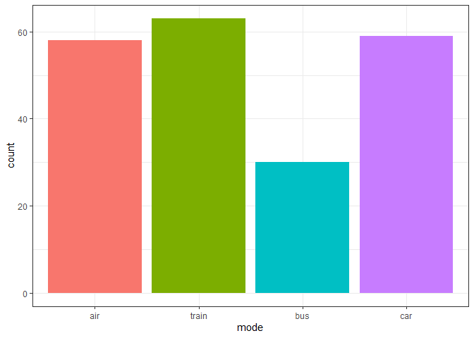

```r
ggplot(TravelMode |> filter(choice=="yes"))+
  geom_bar(aes(mode, fill=mode), show.legend = FALSE)+
  theme_bw()
```

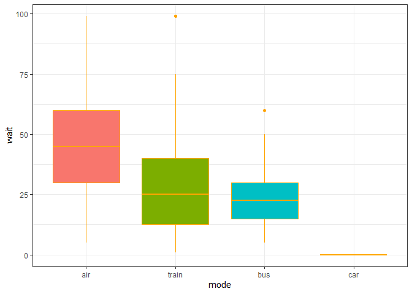

```r
ggplot(TravelMode |> filter(choice=="yes"))+
  geom_boxplot(aes(mode,wait, fill=mode), show.legend = FALSE, color="orange")+
  theme_bw()
```

```r
#con variable "wait"
```

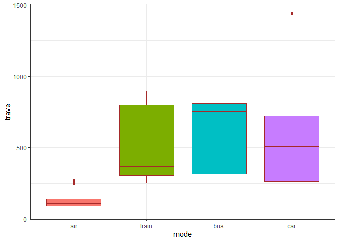

```r
ggplot(TravelMode |> filter(choice=="yes"))+
  geom_boxplot(aes(mode,travel, fill=mode),
               show.legend = FALSE, color="brown")+
  theme_bw()
```

```r
#con variable "travel"
```

## Modelo anidado

```r
nl1 <- mlogit(choice ~ vcost+travel+wait, TM, nests = list(set1=c('bus', 'train'), set2 = c( 'air', 'car')), steptol=1e-12)

summary(nl1)
```

```
##
## Call:
## mlogit(formula = choice ~ vcost + travel + wait, data = TM, nests = list(set1 = c("bus",
##     "train"), set2 = c("air", "car")), steptol = 1e-12)
##
## Frequencies of alternatives:choice
##     air   train     bus     car
## 0.27619 0.30000 0.14286 0.28095
##
## bfgs method
## 16 iterations, 0h:0m:0s
## g'(-H)^-1g = 7.08E-07
## gradient close to zero
##
## Coefficients :
##                     Estimate Std. Error z-value  Pr(>|z|)
## (Intercept):train  1.7934424  1.2775679  1.4038 0.1603802
## (Intercept):bus    1.0464342  1.3096027  0.7990 0.4242631
## (Intercept):car   -3.8913188  1.1792231 -3.2999 0.0009672 ***
## vcost             -0.0207821  0.0091370 -2.2745 0.0229368 *
## travel            -0.0081708  0.0018865 -4.3313 1.483e-05 ***
## wait              -0.1199401  0.0217870 -5.5051 3.689e-08 ***
## iv:set1            1.0483357  0.3449713  3.0389 0.0023744 **
## iv:set2            2.4845061  0.7116251  3.4913 0.0004807 ***
## ---
## Signif. codes:  0 '***' 0.001 '**' 0.01 '*' 0.05 '.' 0.1 ' ' 1
##
## Log-Likelihood: -186.16
## McFadden R^2:  0.34394
## Likelihood ratio test : chisq = 195.19 (p.value = < 2.22e-16)
```

## Modelo logit considerando el costo

```r
ml1 <- mlogit(choice ~
                vcost+travel+gcost, TM)
summary(ml1)
```

```
##
## Call:
## mlogit(formula = choice ~ vcost + travel + gcost, data = TM,
##     method = "nr")
##
## Frequencies of alternatives:choice
##     air   train     bus     car
## 0.27619 0.30000 0.14286 0.28095
##
## nr method
## 4 iterations, 0h:0m:0s
## g'(-H)^-1g = 4.58E-05
## successive function values within tolerance limits
##
## Coefficients :
##                     Estimate Std. Error z-value  Pr(>|z|)
## (Intercept):train  1.3391371  0.4447817  3.0108 0.0026058 **
## (Intercept):bus    0.3768938  0.5116930  0.7366 0.4613885
## (Intercept):car    0.5356920  0.5106626  1.0490 0.2941719
## vcost             -0.0489855  0.0160007 -3.0615 0.0022026 **
## travel            -0.0077034  0.0020136 -3.8257 0.0001304 ***
## gcost              0.0283620  0.0139609  2.0315 0.0422005 *
## ---
## Signif. codes:  0 '***' 0.001 '**' 0.01 '*' 0.05 '.' 0.1 ' ' 1
##
## Log-Likelihood: -261.99
## McFadden R^2:  0.076717
## Likelihood ratio test : chisq = 43.538 (p.value = 1.8914e-09)
```

## Modelo logit multinomial, considerando travel como atributo del decisor

```r
ml2 <- mlogit(choice ~
                vcost+wait+gcost|travel, TM)
summary(ml2)
```

```
##
## Call:
## mlogit(formula = choice ~ vcost + wait + gcost | travel, data = TM,
##     method = "nr")
##
## Frequencies of alternatives:choice
##     air   train     bus     car
## 0.27619 0.30000 0.14286 0.28095
##
## nr method
## 5 iterations, 0h:0m:0s
## g'(-H)^-1g = 0.000168
## successive function values within tolerance limits
##
## Coefficients :
##                     Estimate Std. Error z-value  Pr(>|z|)
## (Intercept):train -1.0078789  0.7903331 -1.2753 0.2022178
## (Intercept):bus   -1.6194694  0.9533642 -1.6987 0.0893778 .
## (Intercept):car   -4.6891775  0.9002021 -5.2090 1.898e-07 ***
## vcost             -0.0484571  0.0179485 -2.6998 0.0069385 **
## wait              -0.1028172  0.0108667 -9.4617 < 2.2e-16 ***
## gcost              0.0320189  0.0155890  2.0539 0.0399808 *
## travel:train      -0.0063925  0.0020582 -3.1059 0.0018968 **
## travel:bus        -0.0065239  0.0021987 -2.9671 0.0030063 **
## travel:car        -0.0073785  0.0021300 -3.4640 0.0005322 ***
## ---
## Signif. codes:  0 '***' 0.001 '**' 0.01 '*' 0.05 '.' 0.1 ' ' 1
##
## Log-Likelihood: -193.44
## McFadden R^2:  0.31828
## Likelihood ratio test : chisq = 180.63 (p.value = < 2.22e-16)
```

```r
ml3 <- mlogit(choice ~
                gcost+wait|vcost, TM)
summary(ml3)
```

```
##
## Call:
## mlogit(formula = choice ~ gcost + wait | vcost, data = TM, method = "nr")
##
## Frequencies of alternatives:choice
##     air   train     bus     car
## 0.27619 0.30000 0.14286 0.28095
##
## nr method
## 5 iterations, 0h:0m:0s
## g'(-H)^-1g = 0.000181
## successive function values within tolerance limits
##
## Coefficients :
##                     Estimate Std. Error z-value  Pr(>|z|)
## (Intercept):train -0.3943958  0.5473951 -0.7205 0.4712198
## (Intercept):bus   -1.3413795  0.8218883 -1.6321 0.1026647
## (Intercept):car   -4.3369468  0.7298488 -5.9423 2.811e-09 ***
## gcost             -0.0013524  0.0057777 -0.2341 0.8149292
## wait              -0.0944150  0.0102984 -9.1679 < 2.2e-16 ***
## vcost:train       -0.0361917  0.0102690 -3.5244 0.0004245 ***
## vcost:bus         -0.0401585  0.0218583 -1.8372 0.0661771 .
## vcost:car         -0.0629273  0.0172861 -3.6403 0.0002723 ***
## ---
## Signif. codes:  0 '***' 0.001 '**' 0.01 '*' 0.05 '.' 0.1 ' ' 1
##
## Log-Likelihood: -189.74
## McFadden R^2:  0.33133
## Likelihood ratio test : chisq = 188.04 (p.value = < 2.22e-16)
```

```r
# Retrieve the estimated parameters
mu <- coef(TM)['wait']
sigma <- coef(TM)['sd.wait']

# Create a data frame for plotting
df <- data.frame(x =seq(from = -0.6, to = 0.2, by = 0.005)) %>%

# Draw from the normal distribution for x given the mean and sd
      mutate(normal = dnorm(x, mean = 0.5, sd = 1))

# Same, but only positive values of x
df_p <- data.frame(x = seq(from = 0, to = 0.2, by = 0.005)) %>%
        mutate(normal = dnorm(x, mean = 05, sd = 1))
```

## Gráfica

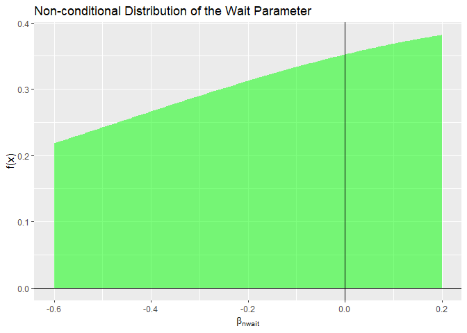

```r
# Plot
ggplot() +

# Plot the distribution
   geom_area(data = df, aes(x = x, y = normal), fill = "green", alpha = 0.5) +

# Plot the distribution for positive values of x only
   geom_area(data = df_p, aes(x = x, y = normal), fill = "red", alpha = 0.5) +

   geom_hline(yintercept = 0) + # Add y axis
   geom_vline(xintercept = 0) + # Add x axis
   ylab("f(x)") + # Label the y axis

   xlab(expression(beta[n][wait])) + # Label the x axis
   ggtitle("Non-conditional Distribution of the Wait Parameter")
```

```r
# Define parameters for the distribution of willingness to pay
mu <- coef(TM)['wait'] / coef(TM)['vcost']

sigma <- sqrt(coef(TM)['sd.wait']^2/ coef(TM)['vcost']^2)

# Create a data frame for plotting
df <- data.frame(x =seq(from = -10, to = 30, by = 0.1)) %>%
mutate(normal = dnorm(x, mean = 0.5, sd = 1))
```

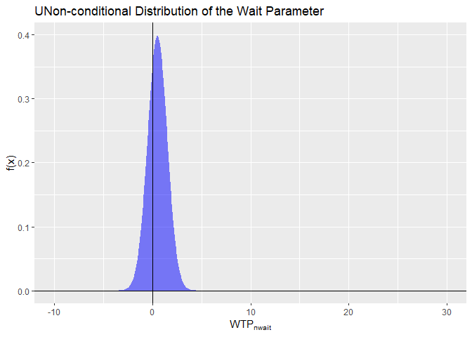

```r
# Plot
ggplot() +
geom_area(data = df, aes(x, normal), fill = "BLUE", alpha = 0.5) +

# geom_area(data = df_p, aes(x, normal), fill = "orange", alpha = 0.5) +
#ylim(c(0, 1/(2 * L) + 0.2 * 1/(2 * L))) + # Set the limits of the y axis

geom_hline(yintercept = 0) + # Add y axis
geom_vline(xintercept = 0) + # Add x axis
ylab("f(x)") + # Label the y axis
xlab(expression(WTP[n][wait])) + # Label the x axis
ggtitle("UNon-conditional Distribution of the Wait Parameter")
```